# Assignment 03: ML Exercise

Author

Muhammad Al Hasib

## Setup: Packages and data

```r
library(haven)
library(tidyverse)
```

```r
TEDS_2016 <- read_stata("https://github.com/datageneration/home/blob/master/DataProgramming/data/TEDS_2016.dta?raw=true")
```

## Multiple regression model

Using `votetsai` as the dependent variable and `age`, `edu`, and `income` as predictors.

```r
model <- lm(votetsai ~ age + edu + income, data = TEDS_2016)
summary(model)
```

```
Call:
lm(formula = votetsai ~ age + edu + income, data = TEDS_2016)

Residuals:
    Min      1Q  Median      3Q     Max
-0.8095 -0.5806  0.3123  0.3751  0.6035

Coefficients:
             Estimate Std. Error t value Pr(>|t|)
(Intercept)  1.085494   0.085071  12.760  < 2e-16 ***
age         -0.005045   0.001058  -4.766 2.10e-06 ***
edu         -0.055280   0.012286  -4.499 7.45e-06 ***
income      -0.004692   0.005155  -0.910    0.363
---
Signif. codes:  0 '***' 0.001 '**' 0.01 '*' 0.05 '.' 0.1 ' ' 1

Residual standard error: 0.4789 on 1253 degrees of freedom
  (433 observations deleted due to missingness)
Multiple R-squared:  0.02362,   Adjusted R-squared:  0.02128
F-statistic:  10.1 on 3 and 1253 DF,  p-value: 1.407e-06
```

## The `regplot` Function

Creating a function that combines `lm()`, `plot()`, and `abline()` to plot a regression fit line.

```r
regplot <- function(x, y) {
  fit <- lm(y ~ x)
  plot(x, y)
  abline(fit, col = "red")
}
```

## Running `regplot` on the dependent variable

### a. Vote Choice by Age

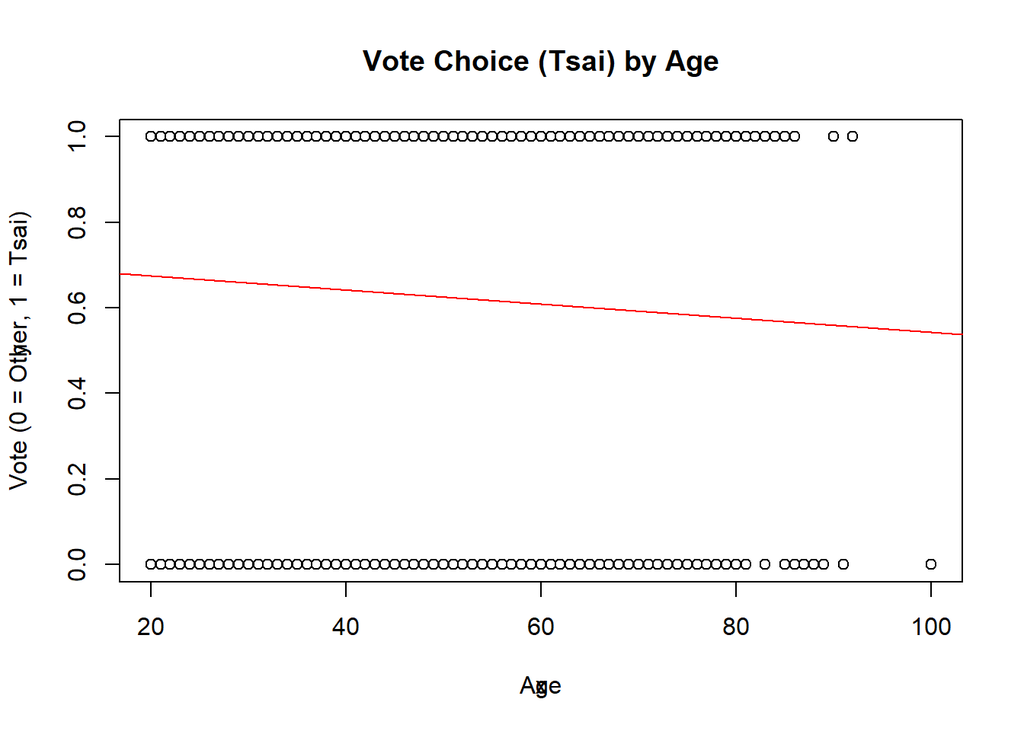

```r
regplot(TEDS_2016$age, TEDS_2016$votetsai)
title(main = "Vote Choice (Tsai) by Age",
      xlab = "Age", ylab = "Vote (0 = Other, 1 = Tsai)")
```

### b. Vote Choice by Education

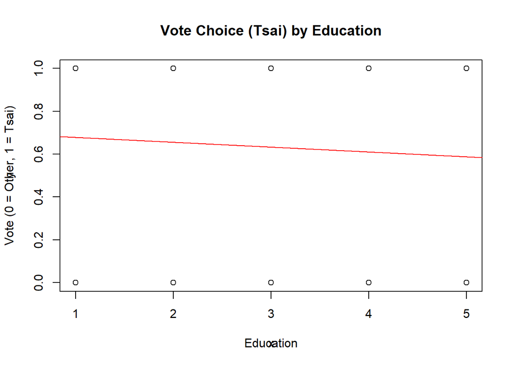

```r
regplot(TEDS_2016$edu, TEDS_2016$votetsai)
title(main = "Vote Choice (Tsai) by Education",
      xlab = "Education", ylab = "Vote (0 = Other, 1 = Tsai)")
```

### c. Vote Choice by Income

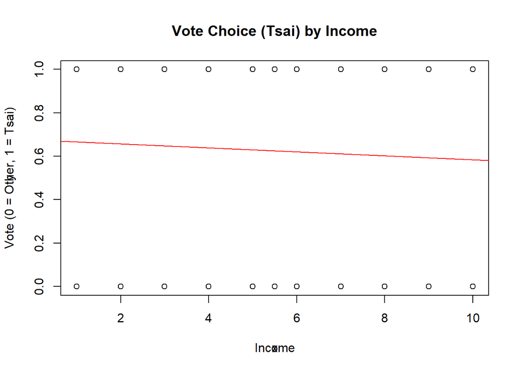

```r
regplot(TEDS_2016$income, TEDS_2016$votetsai)
title(main = "Vote Choice (Tsai) by Income",
      xlab = "Income", ylab = "Vote (0 = Other, 1 = Tsai)")
```

## The problem

The problem is that the dependent variable `votetsai` is **binary** (0 = voted for other candidate, 1 = voted for Tsai Ing-wen). Linear regression assumes the outcome is **continuous**, so applying it to a binary variable produces several issues:

- The regression line can predict values **outside the range of 0 and 1**, which are not valid probabilities
- The relationship between predictors and a binary outcome is inherently **non-linear**
- The assumption of **normally distributed residuals** is violated since the DV only takes two values
- This makes the regression line a poor and misleading fit, as visible in the plots above, where data points cluster at 0 and 1 but the fitted line cuts through the middle

## Measures to improve prediction

Since the dependent variable is binary, **logistic regression** is the appropriate model. It models the **log-odds** of the outcome and constrains all predictions between 0 and 1.

```r
logit_model <- glm(votetsai ~ age + edu + income,
                   data = TEDS_2016,
                   family = binomial)
summary(logit_model)
```

```
Call:
glm(formula = votetsai ~ age + edu + income, family = binomial,
    data = TEDS_2016)

Coefficients:
             Estimate Std. Error z value Pr(>|z|)
(Intercept)  2.508583   0.379569   6.609 3.87e-11 ***
age         -0.021731   0.004656  -4.668 3.05e-06 ***
edu         -0.238448   0.054069  -4.410 1.03e-05 ***
income      -0.020470   0.022460  -0.911    0.362
---
Signif. codes:  0 '***' 0.001 '**' 0.01 '*' 0.05 '.' 0.1 ' ' 1

(Dispersion parameter for binomial family taken to be 1)

    Null deviance: 1661.8  on 1256  degrees of freedom
Residual deviance: 1632.0  on 1253  degrees of freedom
  (433 observations deleted due to missingness)
AIC: 1640

Number of Fisher Scoring iterations: 4
```

### Logistic regression plots

```r
TEDS_2016_clean <- TEDS_2016 %>%
  dplyr::select(votetsai, age, edu, income) %>%
  drop_na()
```

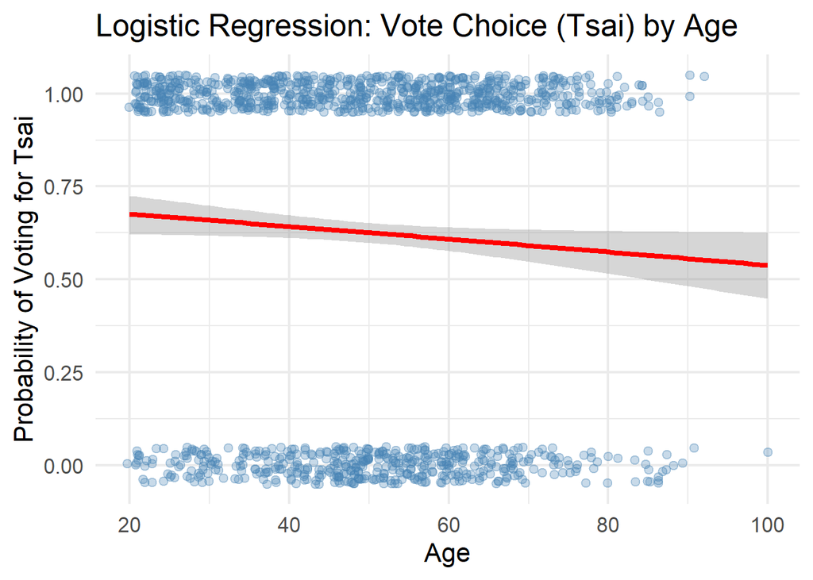

```r
ggplot(TEDS_2016_clean, aes(x = age, y = votetsai)) +
  geom_jitter(height = 0.05, alpha = 0.3, color = "steelblue") +
  geom_smooth(method = "glm",
              method.args = list(family = binomial),
              se = TRUE,
              color = "red") +
  labs(title = "Logistic Regression: Vote Choice (Tsai) by Age",
       x = "Age", y = "Probability of Voting for Tsai") +
  theme_minimal(base_size = 16)
```

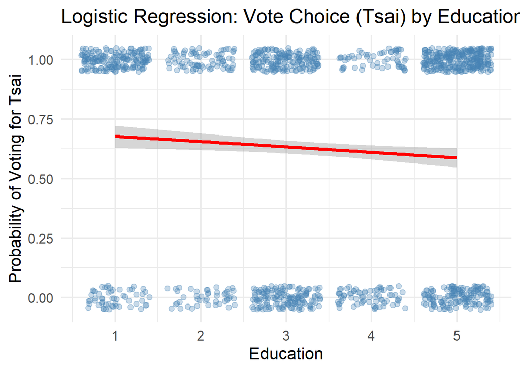

```r
ggplot(TEDS_2016_clean, aes(x = edu, y = votetsai)) +
  geom_jitter(height = 0.05, alpha = 0.3, color = "steelblue") +
  geom_smooth(method = "glm",
              method.args = list(family = binomial),
              se = TRUE,
              color = "red") +
  labs(title = "Logistic Regression: Vote Choice (Tsai) by Education",
       x = "Education", y = "Probability of Voting for Tsai") +
  theme_minimal(base_size = 16)
```

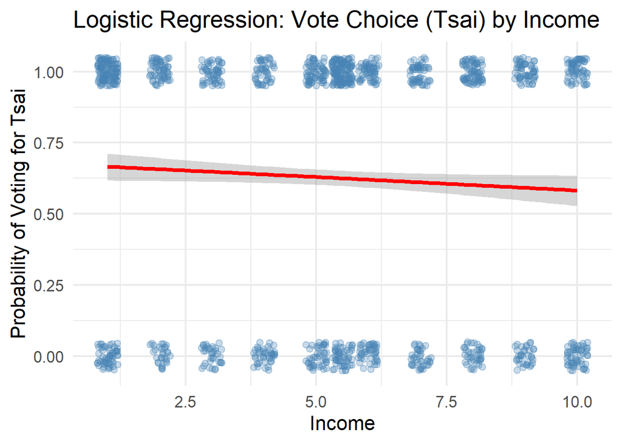

```r
ggplot(TEDS_2016_clean, aes(x = income, y = votetsai)) +
  geom_jitter(height = 0.05, alpha = 0.3, color = "steelblue") +
  geom_smooth(method = "glm",
              method.args = list(family = binomial),
              se = TRUE,
              color = "red") +
  labs(title = "Logistic Regression: Vote Choice (Tsai) by Income",
       x = "Income", y = "Probability of Voting for Tsai") +
  theme_minimal(base_size = 16)
```